- ES218 Home
- [Moodle](https://moodle.colby.edu/course/view.php?id=8060)
- Data sets

# Visualizing univariate distributions

This tutorial makes use of the following R package(s): **`dplyr`**, **`tidyr`**, **`ggplot2`**.

This material is intended to supplement **sections 2.1 and 2.3** of **Cleveland’s book**.

# Introduction

Let’s create two batches of numbers, `a` and `b`:

```r
a  <- rep(12, 10)
b  <- rep(15, 10)
df <- data.frame(a,b)
```

How do the two batches differ?

| a | b |
| --- | --- |
| 12 | 15 |
| 12 | 15 |
| 12 | 15 |
| 12 | 15 |
| 12 | 15 |
| 12 | 15 |
| 12 | 15 |
| 12 | 15 |
| 12 | 15 |
| 12 | 15 |

If the difference wasn’t obvious from the table view we can create a jittered point plot from the data.

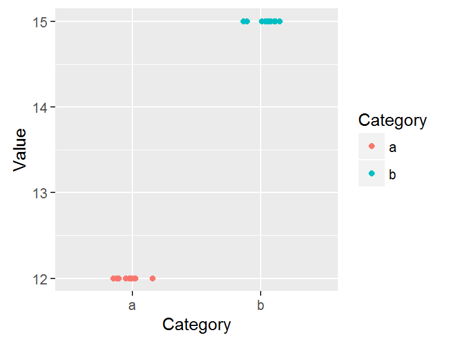

```r
# To plot across categories, we need the data in a long (tidy) form
library(tidyr)
library(ggplot2)

dfl <- gather(df, key=Category, value=Value)
ggplot(dfl,  aes(y = Value, x = Category, col=Category)) +
             geom_jitter(position = position_jitter(height = 0, width=0.4))
```

It’s clear that both batches differ by their uniform values, batch `a` is made up of the identical numbers, `12`, and batch `b` is made up of a different set of identical values, `15`. Note that because so many values overlapped, we made use of the `geom_jitter()` function which randomly *jitters* or nudges the data about its actual location.

Now let’s compare a more complicated batch of numbers.

```r
# Randomly pick 10 values from a uniform distribution
set.seed(23)
a   <- round(runif(10, 5, 15))
b   <- round(runif(10, 10, 20))
# Create wide and long data frames
df  <- data.frame(a,b)
dfl <- gather(df, key=Category, value=Value)
```

| a | b |
| --- | --- |
| 11 | 19 |
| 7 | 17 |
| 8 | 14 |
| 12 | 13 |
| 13 | 18 |
| 9 | 11 |
| 15 | 15 |
| 15 | 16 |
| 13 | 19 |
| 15 | 16 |

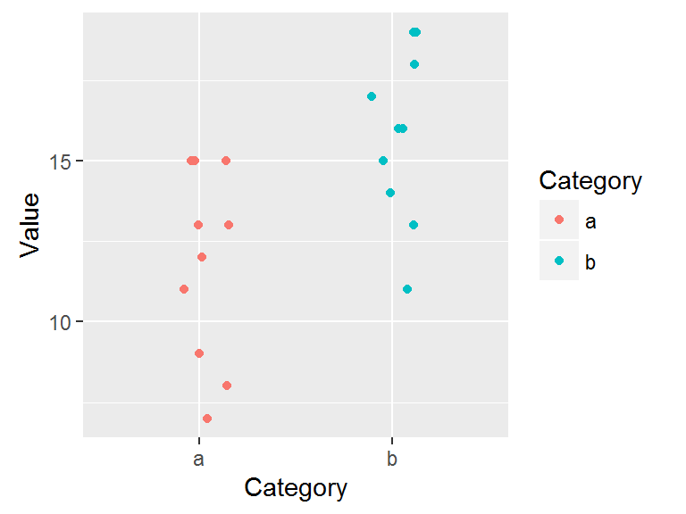

```r
ggplot(dfl, aes(y = Value, x = Category, col=Category)) +
              geom_jitter(position = position_jitter(height = 0, width=0.4))
```

So how do these batches differ? They seem to differ by their center value. For example, each batch’s mean is:

```r
library(dplyr)
dfl %>% group_by(Category) %>% summarize(mean = mean(Value) )
```

```
Source: local data frame [2 x 2]

  Category  mean
     (chr) (dbl)
1        a  11.8
2        b  15.8
```

The center value, or **location** (as Cleveland calls it), is one summary statistic we can use to compare batches, but this may not always be enough. For example, does the **spread** or distribution of the batches differ? It’s difficult to tell given that the batches are offset, so we’ll **level** the batches by subtracting the means from their respective batches.

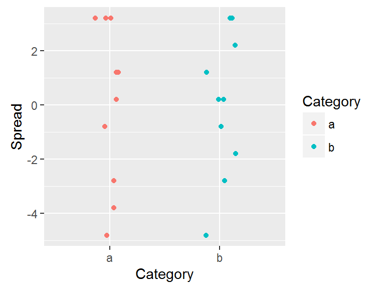

```r
# Subtract the mean from each value for both a and b
dfl2 <- dfl %>%
  group_by(Category) %>%
  mutate( Spread = Value - mean(Value))

# Now plot the leveled batches
ggplot(dfl2, aes(y = Spread, x = Category, col=Category)) +
  geom_jitter(position = position_jitter(height = 0, width=0.4))
```

Removing the *location* (or mean) from each value facilitates the comparison of spread. But we are still in need of a small arsenal of tools that will help us explore and quantify a dataset’s spread. Three such tools that we will explore next are the **histogram**, the **boxplot** and the **quantile plot**.

# Histograms

A histogram **bins** the values (usually in equal sized bins) and plots the frequency in which each *bin* is filled. For example, to create a histogram of batch `a` where each bin size covers **one** unit, we type:

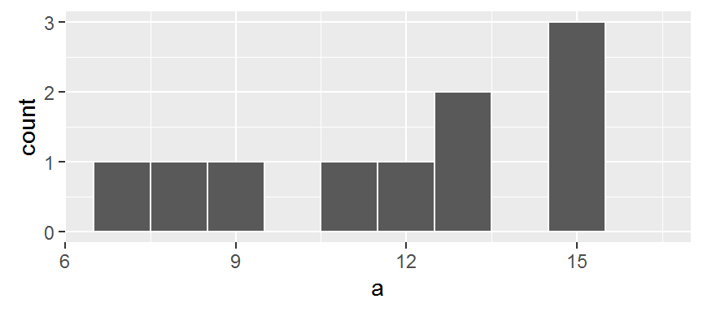

```r
ggplot(df, aes(x=a)) + geom_histogram(breaks = seq(6.5,16.5,by=1), colour="white")
```

We have one value that falls in the first bin (bin ranging from 6.5 to 7.5), another value that falls in the second bin (bin value ranging from 7.5 to 8.5) and so on until the second to last bin which has 3 values falling in it (bin covering the range 14.5 to 15.5). Note in the parameter `seq(6.5, 16.5, by=1)` we are defining the last bin as covering a range from 15.5 to 16.5 which ends up not receiving a value, hence no grey bar on the plot at that location. The parameter `colour=` defines the outline color.

We can modify the width of each bin. For example, to have each bin cover two units instead of one, type:

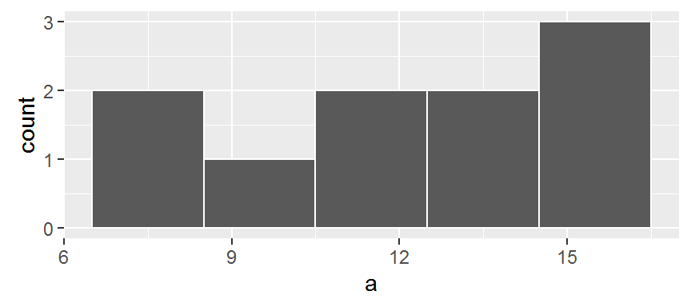

```r
ggplot(df, aes(x=a)) +geom_histogram(breaks = seq(6.5,16.5,by=2), colour="white")
```

You’ll note that changing bin widths can alter the look of the histogram, this is particularly true when plotting large batches of values.

You can also opt to have the function determine the bin ranges by simply specifying the number of bins using the `bin=` parameter:

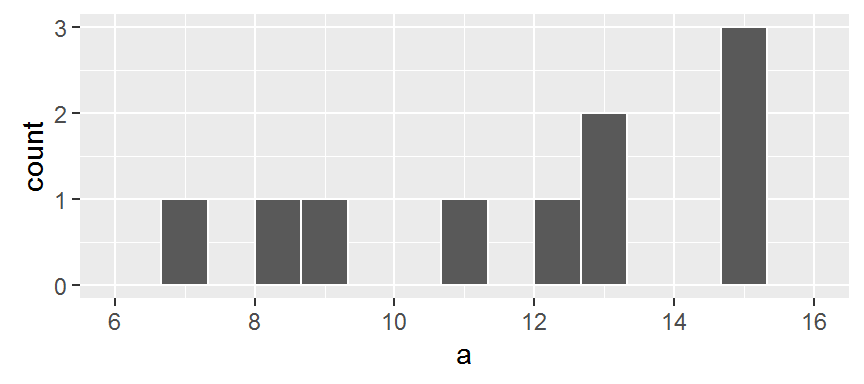

```r
ggplot(df, aes(x=a)) +geom_histogram(bins=12, colour="white")
```

# Boxplots

A boxplot is another popular plot used to explore distributions. In `ggplot` we use the `geom_boxplot()` function as in,

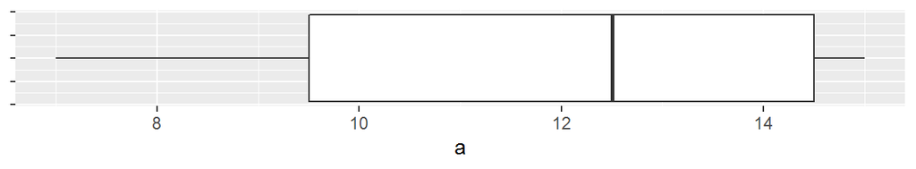

```r
ggplot(df, aes(x=1, y=a)) + geom_boxplot() +
           xlab(NULL) + theme(axis.text.y=element_blank()) +
           coord_flip()
```

Note that the `coord_flip()` function flips the boxplot on its side (the boxplot is normally plotted upright). The `geom_boxplot` function requires that both x and y axes be mapped a variable; usually, the x-axis is assigned a category, but since we are looking at a unique batch, we artifically map a value of 1 to the x-axis (we could have used any value). This requires that we mask the x-axis’s label and text so as not to confuse the reader using the the options `xlab(NULL) + theme(axis.text.y=element_blank())`.

The following figure describes the anatomy of a boxplot.

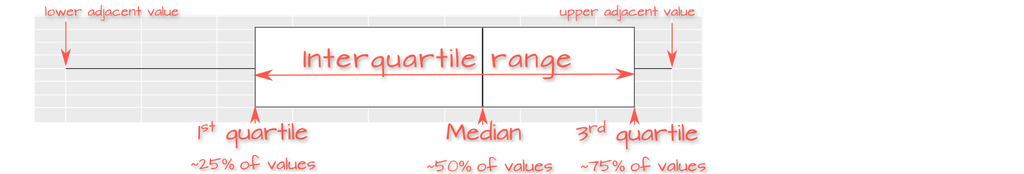

The boxplot provides us with many meaningful pieces of information. For example, it gives us a center value: the median. It also tells us where the middle 50% of the values lie along the full range of values (in our example, approximately 50% of the values lie between 9.5 and 14.5). This range is referred to as the **interquartile** range (or **IQR** for short). Note that this is only an approximation given that some datasets may not lend themselves well to defining exactly 50% of their central values. In our example, only four data points fall within the interquartile range.

The long narrow lines extending beyond the interquartile range are sometimes referred to as **whiskers** and are about 1.5 times the width of the interquartile range or the most extreme value, whichever comes first.

Sometimes, you will encounter values that fall outside of the lower and/or upper adjacent values (aka whiskers); such values are often labeled as “outliers”.

## Not all boxplots are created equal!

Not all boxplots are created equal. There are many different ways in which quantiles can be defined. For example, William Cleveland computes a quantile as $( i - 0.5) / n$ where $i$ is the n<sup>th</sup> element of the batch of data and $n$ is the total number of elements in that batch. The base’s plotting function `boxplot` will generate a different output from that of `ggplot`’s:

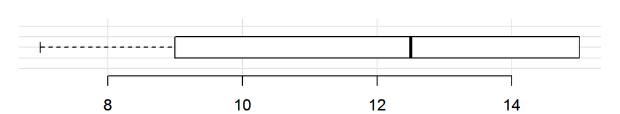

```r
boxplot(a, horizontal = TRUE, add=TRUE)
```

The upper and lower quartiles differ from those of `ggplot`, this is because there are many ways to define a quartile given the batch’s characteristics (e.g. odd vs even number of values, identical values vs unique values, etc…). In most cases the difference will not matter as long as you *adopt the same boxplot procedure when comparing batches*.

# Quantile plots

In his book, Cleveland introduces you to the quantile plot which gives you the quantile of a value in a batch. The boxplot is a special case of the $f$-quantile function in that it only returns the 1<sup>st</sup>, 2<sup>nd</sup> and 3<sup>rd</sup> quantile. The $f$-quantile returns the $full$ range of quantile values. The quantile is directly related to the concept of a percentile: it identifies the fraction of the batch of numbers that is less than a value of interest. The following figure describes the anatomy of a quantile plot.

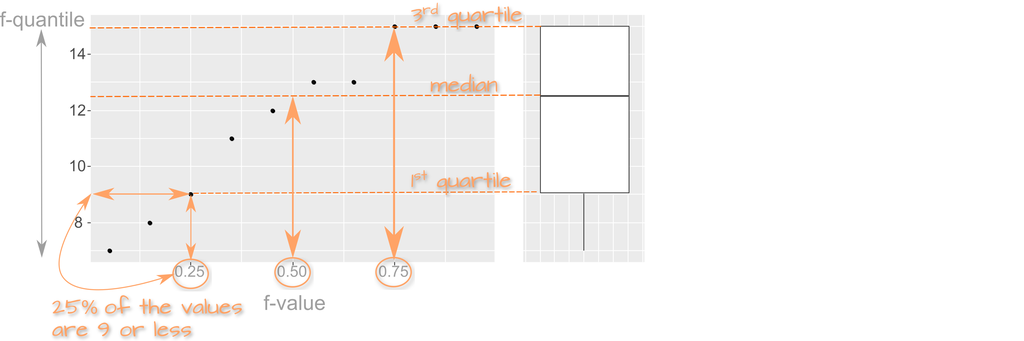

## Computing the $f$-quantile

Computing $f$ requires that the batch of numbers be ordered from smallest to largest.

```r
a.o <- sort(a)
a.o
```

```
 [1]  7  8  9 11 12 13 13 15 15 15
```

The concept of sorting values may seem benign, but it is fundamental to many EDA procedures that require robust techniques.

With the numbers sorted, we can proceed with the computation of $f$, following Cleveland’s formula from page 18:

$$f_i = \frac{i - 0.5}{n}$$

where $i$ is the n<sup>th</sup> element of the batch of data and $n$ is the total number of elements in that batch. As noted in the Boxplots section, there are many ways one can compute a quantile, however, the differences may not matter much.

For each value in `a`, the $f$ value is thus:

```r
i    <- 1 : length(a)
fi   <- (i - 0.5) / length(a)
a.fi <- data.frame(a.o , fi)
```

Note that in the last line of code, we are appending the ordered representation of `a` to `fi` given that `fi` assumes an ordered dataset. The data frame `a.fi` should look like this:

| a.o | fi |
| --- | --- |
| 7 | 0.05 |
| 8 | 0.15 |
| 9 | 0.25 |
| 11 | 0.35 |
| 12 | 0.45 |
| 13 | 0.55 |
| 13 | 0.65 |
| 15 | 0.75 |
| 15 | 0.85 |
| 15 | 0.95 |

It may be desirable at times to find a value associated with a quantile that might not necessarily match an exact value in our batch. For example, there is no value in `a` associated with a quantile of $0.5$; this is because we have an even number of values in our dataset. The solution is to interpolate (or extrapolate) a value based on a desired quantile. The `quantile()` function does just that. For example, to find the value associated with a quantile of $0.5$:

```r
quantile( a, 0.5)
```

```
 50%
12.5
```

If we want to get quantile values for a range of fractions, simply wrap the values with the `c()` function:

```r
quantile( a, c(0.25, 0.5, 0.75))
```

```
 25%  50%  75%
 9.5 12.5 14.5
```

The `quantile` function is designed to accept different quantile algorithms. To see the list of algorithm options, type `?quantile` at a command prompt. By default, R adopts algorithm `type = 7`. To adopt Cleveland’s algorithm, set `type = 5`. E.g.:

```r
quantile( a, c(0.25, 0.5, 0.75), type = 5)
```

```
 25%  50%  75%
 9.0 12.5 15.0
```

## Creating a quantile plot

A batch’s quantile is best viewed as a plot where we plot the batch values as a function of the $f$-values:

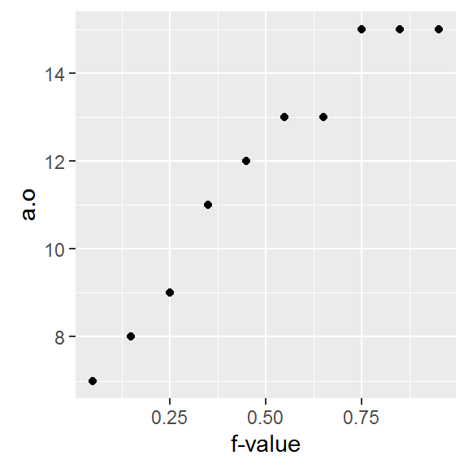

```r
ggplot(a.fi, aes(x=fi, y=a.o)) + geom_point() + xlab("f-value")
```

If you did not want to go through the trouble of computing the $f$-values and the dataframe `a.fi`, you could simply call the function `stat_qq()` as in:

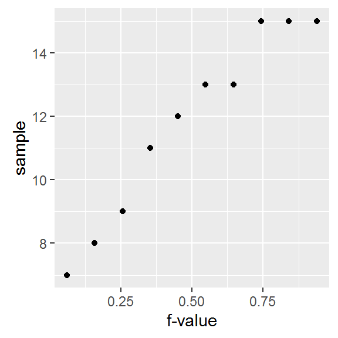

```r
ggplot(df, aes(sample=a)) + stat_qq(distribution = qunif) + xlab("f-value")
```

Note the slight change in mapping values to `aes()`: `sample = a` where `a`is the (unsorted) variable being plotted.

Manny Gimond (2016)